# Subway

15김희지, 31진다환

2018년 11월 2일

15_김희지, 31_진다환

### 수도권 지하철 승/하차 인원 분석

- 퇴근시간 줄서서 기다리던 9호선을 눈앞에서 두번이나 떠나보내야 했던 슬픈이야기…
- [출근길 지옥철, 몸도 인성도 개차반 돼 간다](http://www.ohmynews.com/NWS_Web/View/at_pg.aspx?CNTN_CD=A0002367782)

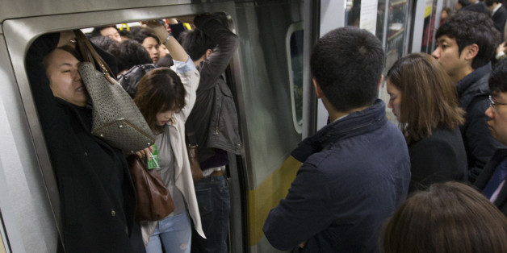

[figure not shown]

## **어떻게 하면 조금이라도 지옥철을 피할 수 있을까?**

```r
library(dplyr)
```

```r
library(ggplot2)
library(gridExtra)
library(tidyr)
library(knitr)
```

### < 데이터 불러들이기 >

### 1. 지하철 호선별 역별 시간대별 승하차 인원 정보

기간 : 15년 1월 ~ 18년 9월  
출처 : [서울시 지하철 호선별 역별 시간대별 승하차 인원 정보](http://data.seoul.go.kr/dataList/datasetView.do?infId=OA-12252&srvType=S&serviceKind=1&currentPageNo=1&searchValue=&searchKey=null)

#### 문제점과 해결

```r
colnames(read.csv("서울시 지하철 호선별 역별 시간대별 승하차 인원 정보.csv"))
```

```
##  [1] "사용월"              "호선명"              "지하철역"
##  [4] "X04시.05시.승차인원" "X04시.05시.하차인원" "X05시.06시.승차인원"
##  [7] "X05시.06시.하차인원" "X06시.07시.승차인원" "X06시.07시.하차인원"
## [10] "X07시.08시.승차인원" "X07시.08시.하차인원" "X08시.09시.승차인원"
## [13] "X08시.09시.하차인원" "X09시.10시.승차인원" "X09시.10시.하차인원"
## [16] "X10시.11시.승차인원" "X10시.11시.하차인원" "X11시.12시.승차인원"
## [19] "X11시.12시.하차인원" "X12시.13시.승차인원" "X12시.13시.하차인원"
## [22] "X13시.14시.승차인원" "X13시.14시.하차인원" "X14시.15시.승차인원"
## [25] "X14시.15시.하차인원" "X15시.16시.승차인원" "X15시.16시.하차인원"
## [28] "X16시.17시.승차인원" "X16시.17시.하차인원" "X17시.18시.승차인원"
## [31] "X17시.18시.하차인원" "X18시.19시.승차인원" "X18시.19시.하차인원"
## [34] "X19시.20시.승차인원" "X19시.20시.하차인원" "X20시.21시.승차인원"
## [37] "X20시.21시.하차인원" "X21시.22시.승차인원" "X21시.22시.하차인원"
## [40] "X22시.23시.승차인원" "X22시.23시.하차인원" "X23시.24시.승차인원"
## [43] "X23시.24시.하차인원" "X00시.01시.승차인원" "X00시.01시.하차인원"
## [46] "X01시.02시.승차인원" "X01시.02시.하차인원" "X02시.03시.승차인원"
## [49] "X02시.03시.하차인원" "X03시.04시.승차인원" "X03시.04시.하차인원"
## [52] "작업일자"
```

- 문제점  
  숫자로 시작되는 열 이름에 x가 포함되어서 출력되었다.

```r
subway <- read.csv("서울시 지하철 호선별 역별 시간대별 승하차 인원 정보.csv", check.names=FALSE)
colnames(subway) #열 이름 확인
```

```
##  [1] "사용월"             "호선명"             "지하철역"
##  [4] "04시-05시 승차인원" "04시-05시 하차인원" "05시-06시 승차인원"
##  [7] "05시-06시 하차인원" "06시-07시 승차인원" "06시-07시 하차인원"
## [10] "07시-08시 승차인원" "07시-08시 하차인원" "08시-09시 승차인원"
## [13] "08시-09시 하차인원" "09시-10시 승차인원" "09시-10시 하차인원"
## [16] "10시-11시 승차인원" "10시-11시 하차인원" "11시-12시 승차인원"
## [19] "11시-12시 하차인원" "12시-13시 승차인원" "12시-13시 하차인원"
## [22] "13시-14시 승차인원" "13시-14시 하차인원" "14시-15시 승차인원"
## [25] "14시-15시 하차인원" "15시-16시 승차인원" "15시-16시 하차인원"
## [28] "16시-17시 승차인원" "16시-17시 하차인원" "17시-18시 승차인원"
## [31] "17시-18시 하차인원" "18시-19시 승차인원" "18시-19시 하차인원"
## [34] "19시-20시 승차인원" "19시-20시 하차인원" "20시-21시 승차인원"
## [37] "20시-21시 하차인원" "21시-22시 승차인원" "21시-22시 하차인원"
## [40] "22시-23시 승차인원" "22시-23시 하차인원" "23시-24시 승차인원"
## [43] "23시-24시 하차인원" "00시-01시 승차인원" "00시-01시 하차인원"
## [46] "01시-02시 승차인원" "01시-02시 하차인원" "02시-03시 승차인원"
## [49] "02시-03시 하차인원" "03시-04시 승차인원" "03시-04시 하차인원"
## [52] "작업일자"
```

```r
names(subway) <- c("YM", "line", "station", "in0405", "out0405", "in0506", "out0506",
                   "in0607", "out0607", "in0708", "out0708", "in0809", "out0809",
                   "in0910", "out0910", "in1011", "out1011", "in1112", "out1112",
                   "in1213", "out1213", "in1314", "out1314", "in1415", "out1415",
                   "in1516", "out1516", "in1617", "out1617", "in1718", "out1718",
                   "in1819", "out1819", "in1920", "out1920", "in2021", "out2021",
                   "in2122", "out2122", "in2223", "out2223", "in2324", "out2324",
                   "in0001", "out0001", "in0102", "out0102", "in0203", "out0203",
                   "in0304", "out0304", "setymd") #열 명 변경
kable(head(subway, 3))
```

| YM | line | station | in0405 | out0405 | in0506 | out0506 | in0607 | out0607 | in0708 | out0708 | in0809 | out0809 | in0910 | out0910 | in1011 | out1011 | in1112 | out1112 | in1213 | out1213 | in1314 | out1314 | in1415 | out1415 | in1516 | out1516 | in1617 | out1617 | in1718 | … |
| --- | --- | --- | --- | --- | --- | --- | --- | --- | --- | --- | --- | --- | --- | --- | --- | --- | --- | --- | --- | --- | --- | --- | --- | --- | --- | --- | --- | --- | --- | --- |
| 201809 | 1호선 | 신설동 | 278 | 30 | 9028 | 2335 | 10029 | 8702 | 19666 | 27541 | 27320 | 64772 | 21357 | 38107 | 20702 | 24396 | 22814 | 22885 | 24635 | 22509 | 26486 | 22692 | 26451 | 21966 | 28779 | 22795 | 32466 | 22789 | 39991 | … |
| 201809 | 4호선 | 고잔 | 366 | 35 | 4483 | 435 | 12596 | 5220 | 27884 | 11237 | 21468 | 25155 | 15473 | 15214 | 13648 | 13776 | 14139 | 14584 | 13763 | 13185 | 13981 | 13639 | 13631 | 14005 | 14794 | 11861 | 16089 | 12625 | 22045 | … |
| 201809 | 4호선 | 중앙 | 317 | 22 | 7751 | 889 | 21455 | 9798 | 47613 | 15487 | 40296 | 31446 | 25019 | 28020 | 22955 | 22394 | 24741 | 21807 | 26805 | 24700 | 26646 | 28633 | 26207 | 28808 | 27517 | 28442 | 32734 | 33497 | 37403 | … |

- 해결
1. `check.names = F`로 설정하여 열 이름에 x가 포함되지 않게 설정하였다.
2. 열 이름을 변경하였다.

### 2. 1-4호선 지하철역 주소 데이터

```r
add1_4 <- read.csv("서울교통공사 지하철역 주소 및 전화번호 정보.csv") #데이터 불러오기
kable(head(add1_4)) #데이터 확인
```

| 호선 | 역명 | 구주소 | 도로명주소 | 전화번호 |
| --- | --- | --- | --- | --- |
| 1호선 | 청량리 | 서울 동대문구 왕산로 328-1 | 서울특별시 동대문구 왕산로 지하 205 (전농동) (청량리역) | 6110-1241 |
| 1호선 | 제기동 | 서울 동대문구 제기동 지하51번지 | 서울특별시 동대문구 왕산로 지하 93 (제기동) (제기동역) | 6110-1251 |
| 1호선 | 신설동 | 서울 동대문구 신설동 97-75 | 서울특별시 동대문구 왕산로 지하 1 (신설동) (1호선 신설동역) | 6110-1261 |
| 1호선 | 동묘앞 | 서울 종로구 숭인동 117번지 | 서울특별시 종로구 종로 359 (숭인동) (1호선 동묘앞역) | 6110-1271 |
| 1호선 | 동대문 | 서울 종로구 창신1동 552 | 서울특별시 종로구 종로 지하 302 (창신1동) (1호선 동대문역) | 6110-1281 |
| 1호선 | 종로5가 | 서울 종로구 종로5가 124-8 | 서울특별시 종로구 종로 지하 216 (종로5가) (1호선 종로5가역) | 6110-1291 |

```r
add1_4 <- add1_4 %>% select(호선, 역명, 도로명주소) #필요한 열만 선택
names(add1_4) <- c("line", "station", "adrs") #호선, 역명, 도로명주소 컬럼명 변경
```

### 3. 5-8호선 지하철역 주소 데이터

```r
add5_8 <- read.csv("서울교통공사 지하철 역별 주소 정보.csv") #데이터 불러오기
kable(head(add5_8)) #데이터 확인
```

| 연번 | 호선 | 역명 | 도로명주소 | 지번주소 | 우편번호 | 전화번호 |
| --- | --- | --- | --- | --- | --- | --- |
| 1 | 5 | 방화역 | 서울특별시 강서구 금낭화로 지하132 (방화동) | 서울특별시 강서구 방화동 829-15 | 157-857 | 02-6311-5101 |
| 2 | 5 | 개화산역 | 서울특별시 강서구 양천로 22 (방화동) | 서울특별시 강서구 방화동 846 | 157-220 | 02-6311-5111 |
| 3 | 5 | 김포공항역 | 서울특별시 강서구 하늘길 지하77 (방화동) | 서울특별시 강서구 방화동 886 | 157-220 | 02-6311-5121 |
| 4 | 5 | 송정역 | 서울특별시 강서구 공항대로 지하33 (공항동) | 서울특별시 강서구 공항동 29-5 | 157-811 | 02-6311-5131 |
| 5 | 5 | 마곡역 | 서울특별시 강서구 공항대로 지하163 (가양동) | 서울특별시 강서구 가양동 530-6 | 157-805 | 02-6311-5141 |
| 6 | 5 | 발산역 | 서울특별시 강서구 공항대로 지하267 (가양동) | 서울특별시 강서구 가양동 967-3 | 157-805 | 02-6311-5151 |

```r
add5_8 <- add5_8 %>% select(호선, 역명, 도로명주소) #필요한 열만 선택
names(add5_8) <- c("line", "station", "adrs") #호선, 역명, 도로명주소 컬럼명 변경
add5_8$line <- paste(add5_8$line, "호선", sep = "")
```

- 앞의 두 데이터는 line(호선)이 *O호선*으로 나오는 반면 5-8호선 주소 데이터에서는 *O(숫자)* 로 데이터가 표시되었다. 따라서 5-8호선의 line(호선) 열을 *O호선*형태로 수정하였다.

#### 데이터 파악

```r
str((subway)[1:3]) #데이터타입 확인
```

```
## 'data.frame':    25553 obs. of  3 variables:
##  $ YM     : int  201809 201809 201809 201809 201809 201809 201809 201809 201809 201809 ...
##  $ line   : Factor w/ 16 levels "1호선","2호선",..: 1 4 4 4 4 4 4 4 4 15 ...
##  $ station: Factor w/ 509 levels "4.19민주묘지",..: 306 36 441 488 232 179 113 327 218 407 ...
```

```r
str(add1_4) #데이터타입 확인
```

```
## 'data.frame':    121 obs. of  3 variables:
##  $ line   : Factor w/ 4 levels "1호선","2호선",..: 1 1 1 1 1 1 1 1 1 1 ...
##  $ station: Factor w/ 111 levels "가락시장","강남",..: 100 93 64 31 28 96 95 94 57 49 ...
##  $ adrs   : Factor w/ 121 levels " 서울특별시 중구 퇴계로 지하199(충무로역)",..: 38 39 36 104 107 106 105 108 76 77 ...
```

```r
str(add5_8) #데이터타입 확인
```

```
## 'data.frame':    152 obs. of  3 variables:
##  $ line   : chr  "5호선" "5호선" "5호선" "5호선" ...
##  $ station: Factor w/ 152 levels "가락시장역","가산디지털단지역",..: 63 7 24 87 46 61 119 150 25 96 ...
##  $ adrs   : Factor w/ 152 levels "경기도 광명시 오리로 지하980 (광명동)",..: 35 36 37 34 32 33 30 38 31 107 ...
```

```r
subway[2] <- as.character(subway$line)
subway[3] <- as.character(subway$station)
add1_4[1] <- as.character(add1_4$line)
add1_4[2] <- as.character(add1_4$station)
add1_4[3] <- as.character(add1_4$adrs)
add5_8[1] <- as.character(add5_8$line)
add5_8[2] <- as.character(add5_8$station)
add5_8[3] <- as.character(add5_8$adrs)
```

join의 기준이 될 line(호선)과 station(역명)을 factor에서 character로 변환

```r
add <- bind_rows(add1_4, add5_8) #행으로 합치기
total <- left_join(subway, add, by = c("line", "station")) #호선, 역명을 기준으로 join

head(total)
```

```
##       YM  line station in0405 out0405 in0506 out0506 in0607 out0607 in0708
## 1 201809 1호선  신설동    278      30   9028    2335  10029    8702  19666
## 2 201809 4호선    고잔    366      35   4483     435  12596    5220  27884
## 3 201809 4호선    중앙    317      22   7751     889  21455    9798  47613
## 4 201809 4호선  한대앞    201       9   5828    1014  14199    3711  29225
## 5 201809 4호선  상록수    530      43  14881    3236  34658   10180  82078
## 6 201809 4호선    반월      7       0   3308    1237   6986    2959  15991
##   out0708 in0809 out0809 in0910 out0910 in1011 out1011 in1112 out1112
## 1   27541  27320   64772  21357   38107  20702   24396  22814   22885
## 2   11237  21468   25155  15473   15214  13648   13776  14139   14584
## 3   15487  40296   31446  25019   28020  22955   22394  24741   21807
## 4    7627  24828   20495  16957   16247  14607   13108  14126    8701
## 5   16448  78204   28114  48376   25114  36672   20560  33550   18411
## 6    4651  17157    6792  11494    3935   9315    4049   7949    4293
##   in1213 out1213 in1314 out1314 in1415 out1415 in1516 out1516 in1617
```

[output cut: 34 more lines]

### 데이터 살펴보기

```r
sapply(total, class) #데이터 타입 알아보기
```

```
##          YM        line     station      in0405     out0405      in0506
##   "integer" "character" "character"   "integer"   "integer"   "integer"
##     out0506      in0607     out0607      in0708     out0708      in0809
##   "integer"   "integer"   "integer"   "integer"   "integer"   "integer"
##     out0809      in0910     out0910      in1011     out1011      in1112
##   "integer"   "integer"   "integer"   "integer"   "integer"   "integer"
##     out1112      in1213     out1213      in1314     out1314      in1415
##   "integer"   "integer"   "integer"   "integer"   "integer"   "integer"
##     out1415      in1516     out1516      in1617     out1617      in1718
##   "integer"   "integer"   "integer"   "integer"   "integer"   "integer"
##     out1718      in1819     out1819      in1920     out1920      in2021
##   "integer"   "integer"   "integer"   "integer"   "integer"   "integer"
##     out2021      in2122     out2122      in2223     out2223      in2324
##   "integer"   "integer"   "integer"   "integer"   "integer"   "integer"
##     out2324      in0001     out0001      in0102     out0102      in0203
##   "integer"   "integer"   "integer"   "integer"   "integer"   "integer"
##     out0203      in0304     out0304      setymd        adrs
##   "integer"   "integer"   "integer"   "integer" "character"
```

```r
summary(total)
```

```
##        YM             line             station              in0405
##  Min.   :201501   Length:25553       Length:25553       Min.   :    0.0
##  1st Qu.:201512   Class :character   Class :character   1st Qu.:    3.0
##  Median :201611   Mode  :character   Mode  :character   Median :   19.0
##  Mean   :201649                                         Mean   :  193.2
##  3rd Qu.:201711                                         3rd Qu.:  106.0
##  Max.   :201809                                         Max.   :11236.0
##     out0405            in0506         out0506          in0607
##  Min.   :  0.000   Min.   :    0   Min.   :    0   Min.   :    0
##  1st Qu.:  0.000   1st Qu.: 1553   1st Qu.:  400   1st Qu.: 3716
##  Median :  0.000   Median : 3680   Median :  939   Median : 8248
##  Mean   :  2.935   Mean   : 5533   Mean   : 1367   Mean   :11560
##  3rd Qu.:  3.000   3rd Qu.: 7087   3rd Qu.: 1705   3rd Qu.:15448
##  Max.   :170.000   Max.   :59655   Max.   :15843   Max.   :99232
##     out0607          in0708          out0708           in0809
##  Min.   :    0   Min.   :     0   Min.   :     0   Min.   :     0
##  1st Qu.: 2458   1st Qu.:  8604   1st Qu.:  5022   1st Qu.: 10637
##  Median : 5173   Median : 20861   Median : 10388   Median : 23776
##  Mean   : 7584   Mean   : 30396   Mean   : 17606   Mean   : 34219
##  3rd Qu.: 9586   3rd Qu.: 41280   3rd Qu.: 20760   3rd Qu.: 45395
##  Max.   :87300   Max.   :294593   Max.   :238513   Max.   :386398
##     out0809           in0910          out0910           in1011
##  Min.   :     0   Min.   :     0   Min.   :     0   Min.   :     0
##  1st Qu.:  9470   1st Qu.:  7557   1st Qu.:  6085   1st Qu.:  6490
##  Median : 22175   Median : 15796   Median : 14199   Median : 12859
##  Mean   : 40155   Mean   : 21649   Mean   : 26380   Mean   : 16672
##  3rd Qu.: 42829   3rd Qu.: 28187   3rd Qu.: 31105   3rd Qu.: 21905
##  Max.   :465406   Max.   :219085   Max.   :416670   Max.   :122839
##     out1011           in1112          out1112           in1213
##  Min.   :     0   Min.   :     0   Min.   :     0   Min.   :     0
##  1st Qu.:  4983   1st Qu.:  6645   1st Qu.:  4813   1st Qu.:  7113
##  Median : 10687   Median : 12899   Median : 10376   Median : 13947
##  Mean   : 17627   Mean   : 16827   Mean   : 16804   Mean   : 18289
##  3rd Qu.: 21861   3rd Qu.: 21833   3rd Qu.: 21042   3rd Qu.: 23279
##  Max.   :205515   Max.   :114348   Max.   :185602   Max.   :143766
##     out1213           in1314          out1314           in1415
##  Min.   :     0   Min.   :     0   Min.   :     0   Min.   :     0
##  1st Qu.:  5290   1st Qu.:  7124   1st Qu.:  5742   1st Qu.:  6634
##  Median : 11198   Median : 14000   Median : 12009   Median : 13228
##  Mean   : 17527   Mean   : 19317   Mean   : 19107   Mean   : 18929
```

[output cut: 43 more lines]

```
##  Max.   :46252   Max.   :2805.000   Max.   :6651.0   Max.   :3082.0000
##     out0203            in0304            out0304
##  Min.   :  0.000   Min.   : 0.00000   Min.   :  0.0000
##  1st Qu.:  0.000   1st Qu.: 0.00000   1st Qu.:  0.0000
##  Median :  0.000   Median : 0.00000   Median :  0.0000
##  Mean   :  1.733   Mean   : 0.02806   Mean   :  0.1323
##  3rd Qu.:  0.000   3rd Qu.: 0.00000   3rd Qu.:  0.0000
##  Max.   :863.000   Max.   :94.00000   Max.   :312.0000
##      setymd             adrs
##  Min.   :20151208   Length:25553
##  1st Qu.:20160108   Class :character
##  Median :20161208   Mode  :character
##  Mean   :20165686
##  3rd Qu.:20171203
##  Max.   :20181003
```

모든 열에서 min이 0이 되는 것은 사실상 불가능하다.

#### outlier 파악

- 오전7:00 ~ 오후11:59에 승하차 인원이 5 이하일 수 없다.

```r
x <- total %>% filter((in0708 <= 5 | in0809 <= 5 | in0910 <= 5 | in1011 <= 5 | in1112 <= 5 |
                      in1213 <= 5 | in1314 <= 5 | in1415 <= 5 | in1516 <= 5 | in1617 <= 5 |
                      in1718 <= 5 | in1819 <= 5 | in1920 <= 5 | in2021 <= 5 | in2122 <= 5 |
                      in2223 <= 5 | out0708 <= 5 | out0809 <= 5 | out0910 <= 5 | out1011 <= 5 |
                      out1112 <= 5 | out1213 <= 5 | out1314 <= 5 | out1415 <= 5 | out1516 <= 5 |
                      out1617 <= 5 | out1718 <= 5 | out1819 <= 5 | out1920 <= 5 | out2021 <= 5 |
                      out2122 <= 5 | out2223 <= 5 ))
head(x, 3)
```

```
##       YM  line station in0405 out0405 in0506 out0506 in0607 out0607 in0708
## 1 201809 6호선  연신내      0       0      0       0      0       0      0
## 2 201809 3호선  충무로      0       0      0       0      0       0      0
## 3 201809 3호선    지축      0       0      0       0      0       0      0
##   out0708 in0809 out0809 in0910 out0910 in1011 out1011 in1112 out1112
## 1       0      1       0      0       0      4       0      1       0
## 2       0      0       0      2       0      5       0      1       0
## 3       0      0       0      0       0      1       0      0       0
##   in1213 out1213 in1314 out1314 in1415 out1415 in1516 out1516 in1617
## 1      0       0      2       0      1       0      1       0      0
## 2      0       0      4       0      3       0      3       0      4
## 3      0       0      0       0      0       0      0       0      0
##   out1617 in1718 out1718 in1819 out1819 in1920 out1920 in2021 out2021
## 1       0      0       0      3       0      5       0      2       0
## 2       0      5       0      7       0      3       0      5       0
## 3       0      0       0      0       0      0       0      0       0
##   in2122 out2122 in2223 out2223 in2324 out2324 in0001 out0001 in0102
## 1      0       0      5       0      0       0      0       0      0
## 2      2       0      6       0      3       0      2       0      1
## 3      0       0      0       0      0       0      0       0      0
##   out0102 in0203 out0203 in0304 out0304   setymd
## 1       0      0       0      0       0 20181003
## 2       0      0       0      0       0 20181003
## 3       0      0       0      0       0 20181003
##                                        adrs
## 1                                      <NA>
## 2  서울특별시 중구 퇴계로 지하199(충무로역)
## 3  경기도 고양시 덕양구 삼송로 300 (지축역)
```

```r
table(x$line)
```

```
##
##      1호선      3호선      6호선 경의중앙선     분당선     수인선
##         98         63         45        152         41          3
```

```r
table(x$station)
```

```
##
##             검암             계양             공덕             광명
##               20               18               11               23
##         김포공항             달월 디지털미디어시티             복정
##               17                3                5               41
##           서울역           신도림           연신내             옥수
##               46                4               45               31
##             지축             지평             창동           충무로
##               18               21               45               45
##         홍대입구
##                9
```

출처: [위키백과/서울교통공사](https://ko.wikipedia.org/wiki/%EC%84%9C%EC%9A%B8%EA%B5%90%ED%86%B5%EA%B3%B5%EC%82%AC)

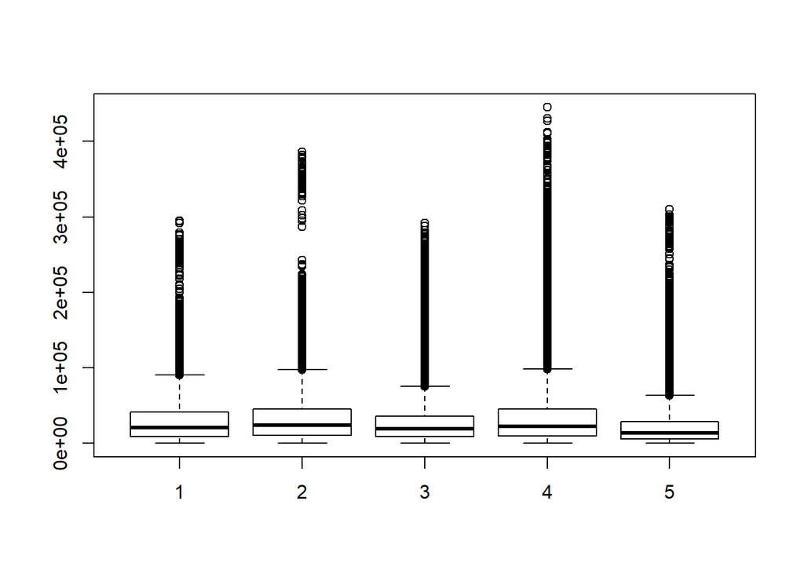

```r
attach(total) #total 부착
boxplot(in0708, in0809, in1718, in1819, in1920) #total 데이터의 출퇴근시간 기준 boxplot
```

```r
detach(total)
```

boxplot을 통해 이상치를 확인하려 했으나 역별 편차가 커서 outlier판단은 불가능하였다.

- oulier 제외

```r
total <- total %>% filter(!(in0708 <= 5 | in0809 <= 5 | in0910 <= 5 | in1011 <= 5
                          | in1112 <= 5 | in1213 <= 5 | in1314 <= 5 | in1415 <= 5
                          | in1516 <= 5 | in1617 <= 5 | in1718 <= 5 | in1819 <= 5
                          | in1920 <= 5 | in2021 <= 5 | in2122 <= 5 | in2223 <= 5
                          | out0708 <= 5 | out0809 <= 5 | out0910 <= 5 | out1011 <= 5
                          | out1112 <= 5 | out1213 <= 5 | out1314 <= 5 | out1415 <= 5
                          | out1516 <= 5 | out1617 <= 5 | out1718 <= 5 | out1819 <= 5
                          | out1920 <= 5 | out2021 <= 5 | out2122 <= 5 | out2223 <= 5 ))
```

#### 결측치 확인하기

```r
colSums(is.na(total))
```

```
##      YM    line station  in0405 out0405  in0506 out0506  in0607 out0607
##       0       0       0       0       0       0       0       0       0
##  in0708 out0708  in0809 out0809  in0910 out0910  in1011 out1011  in1112
##       0       0       0       0       0       0       0       0       0
## out1112  in1213 out1213  in1314 out1314  in1415 out1415  in1516 out1516
##       0       0       0       0       0       0       0       0       0
##  in1617 out1617  in1718 out1718  in1819 out1819  in1920 out1920  in2021
##       0       0       0       0       0       0       0       0       0
## out2021  in2122 out2122  in2223 out2223  in2324 out2324  in0001 out0001
##       0       0       0       0       0       0       0       0       0
##  in0102 out0102  in0203 out0203  in0304 out0304  setymd    adrs
##       0       0       0       0       0       0       0   19844
```

**승/하차 데이터로 분리**

```r
subin <- total %>% select(YM, line, station, in0405, in0506,
                          in0607, in0708, in0809, in0910, in1011,
                          in1112, in1213, in1314, in1415, in1516,
                          in1617, in1718, in1819, in1920, in2021,
                          in2122, in2223, in2324, in0001, in0102,
                          in0203, in0304, adrs) #년월, 호선, 역, 승차시간 열 선택

subout <- total %>% select(YM, line, station, out0405, out0506,
                           out0607, out0708, out0809, out0910,
                           out1011, out1112, out1213, out1314,
                           out1415, out1516, out1617, out1718,
                           out1819, out1920, out2021, out2122,
                           out2223, out2324, out0001, out0102,
                           out0203, out0304, adrs) #년월, 호선, 역, 하차시간 열 선택
```

#### **출퇴근 시간대의 승/하차 인원이 다른 시간대보다 많을 것이다.**

**시간대별 승/하차 인원 평균**

```r
time_in <- subin %>%
  summarise(in0405 = mean(in0405), in0506 = mean(in0506), in0607 = mean(in0607),
            in0708 = mean(in0708), in0809 = mean(in0809), in0910 = mean(in0910),
            in1011 = mean(in1011), in1112 = mean(in1112), in1213 = mean(in1213),
            in1314 = mean(in1314), in1415 = mean(in1415), in1516 = mean(in1516),
            in1617 = mean(in1617), in1718 = mean(in1718), in1819 = mean(in1819),
            in1920 = mean(in1920), in2021 = mean(in2021), in2122 = mean(in2122),
            in2223 = mean(in2223), in2324 = mean(in2324), in0001 = mean(in0001),
            in0102 = mean(in0102), in0203 = mean(in0203), in0304 = mean(in0304))
time_in #시간대별 승차인원 전체 평균
```

```
##    in0405   in0506   in0607   in0708   in0809   in0910   in1011  in1112
## 1 196.305 5621.301 11744.62 30878.09 34762.65 21993.57 16938.49 17096.4
##     in1213   in1314   in1415   in1516   in1617   in1718   in1819   in1920
## 1 18581.61 19625.52 19231.51 20967.78 23720.78 28559.79 39191.54 24685.66
##     in2021   in2122   in2223   in2324   in0001   in0102    in0203
## 1 18960.77 18247.46 15539.59 7095.759 924.6338 5.441334 0.3724703
##       in0304
## 1 0.02846805
```

```r
time_out <- subout %>%
  summarise(out0405 = mean(out0405), out0506 = mean(out0506), out0607 = mean(out0607),
            out0708 = mean(out0708), out0809 = mean(out0809), out0910 = mean(out0910),
            out1011 = mean(out1011), out1112 = mean(out1112), out1213 = mean(out1213),
            out1314 = mean(out1314), out1415 = mean(out1415), out1516 = mean(out1516),
            out1617 = mean(out1617), out1718 = mean(out1718), out1819 = mean(out1819),
            out1920 = mean(out1920), out2021 = mean(out2021), out2122 = mean(out2122),
            out2223 = mean(out2223), out2324 = mean(out2324), out0001 = mean(out0001),
            out0102 = mean(out0102), out0203 = mean(out0203), out0304 = mean(out0304))
time_out #시간대별 하차인원 전체 평균
```

```
##    out0405  out0506  out0607  out0708  out0809  out0910  out1011  out1112
## 1 2.981591 1387.412 7701.315 17885.41 40792.43 26801.59 17908.42 17072.59
##    out1213  out1314  out1415  out1516  out1617 out1718  out1819  out1920
## 1 17806.76 19412.11 19065.24 19719.92 21728.96 25593.2 34753.94 32846.89
##    out2021  out2122  out2223  out2324 out0001  out0102  out0203   out0304
## 1 20746.42 18240.34 17532.03 11889.02 3845.76 131.3885 1.760447 0.1344678
```

데이터가 가로로 길게 나타난 형태이기 때문에 `gather`를 이용하여 세로형으로 변환

```r
time_in <- gather(time_in, key = "time", value = "num", in0405, in0506,
                  in0607, in0708, in0809,in0910, in1011,in1112, in1213,
                  in1314, in1415, in1516, in1617, in1718, in1819, in1920,
                  in2021, in2122, in2223, in2324, in0001, in0102, in0203, in0304)
kable(head(time_in)) #시간대별 승차인원 전체 평균
```

| time | num |
| --- | --- |
| in0405 | 196.305 |
| in0506 | 5621.301 |
| in0607 | 11744.619 |
| in0708 | 30878.094 |
| in0809 | 34762.648 |
| in0910 | 21993.567 |

```r
time_out <- gather(time_out, key = "time", value = "num", out0405, out0506,
                   out0607, out0708, out0809, out0910, out1011, out1112,
                   out1213, out1314, out1415, out1516, out1617, out1718,
                   out1819, out1920, out2021, out2122, out2223, out2324,
                   out0001, out0102, out0203, out0304)
kable(head(time_out)) #시간대별 하차인원 전체 평균
```

| time | num |
| --- | --- |
| out0405 | 2.981591 |
| out0506 | 1387.412469 |
| out0607 | 7701.314500 |
| out0708 | 17885.410322 |
| out0809 | 40792.434496 |
| out0910 | 26801.586577 |

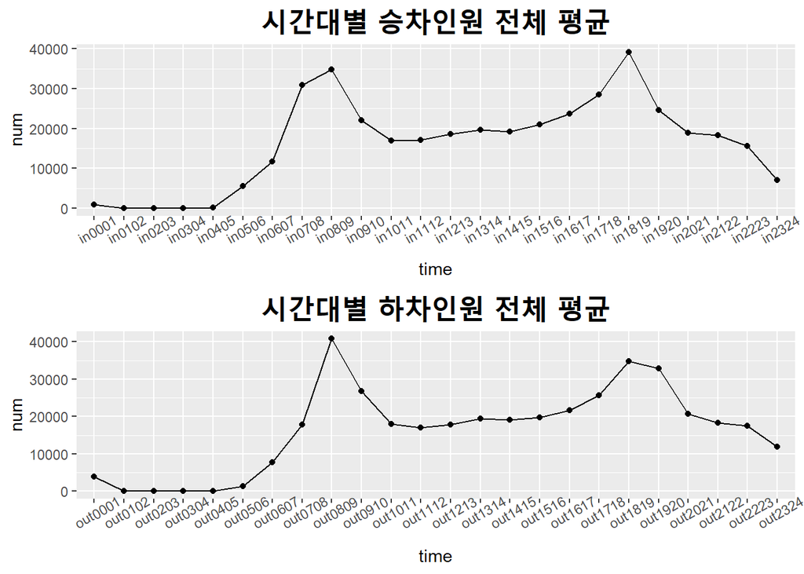

```r
p1 <- ggplot(time_in, aes(x = time, y = num, group = 1)) + geom_point() + geom_line() +
  theme(plot.title = element_text(face = "bold", hjust = 0.5, size = 20),
        axis.text.x = element_text(angle = 30)) +
  ggtitle("시간대별 승차인원 전체 평균")

p2 <- ggplot(time_out, aes(x = time, y = num, group = 1)) + geom_point() + geom_line() +
  theme(plot.title = element_text(face = "bold", hjust = 0.5, size = 20),
        axis.text.x = element_text(angle = 30)) +
  ggtitle("시간대별 하차인원 전체 평균")

grid.arrange(p1, p2, ncol = 1)
```

#### **2호선, 9호선의 승/하차 인원이 다른 호선보다 많을 것이다.**

**호선별 승하차 평균 인원**

```r
subin_gl <- subin %>% group_by(line) %>%
  summarise(in0405 = mean(in0405), in0506 = mean(in0506), in0607 = mean(in0607),
            in0708 = mean(in0708), in0809 = mean(in0809), in0910 = mean(in0910),
            in1011 = mean(in1011), in1112 = mean(in1112), in1213 = mean(in1213),
            in1314 = mean(in1314), in1415 = mean(in1415), in1516 = mean(in1516),
            in1617 = mean(in1617), in1718 = mean(in1718), in1819 = mean(in1819),
            in1920 = mean(in1920), in2021 = mean(in2021), in2122 = mean(in2122),
            in2223 = mean(in2223), in2324 = mean(in2324), in0001 = mean(in0001),
            in0102 = mean(in0102), in0203 = mean(in0203), in0304 = mean(in0304))

subout_gl <- subout %>% group_by(line) %>%
  summarise(out0405 = mean(out0405), out0506 = mean(out0506), out0607 = mean(out0607),
            out0708 = mean(out0708), out0809 = mean(out0809), out0910 = mean(out0910),
            out1011 = mean(out1011), out1112 = mean(out1112), out1213 = mean(out1213),
            out1314 = mean(out1314), out1415 = mean(out1415), out1516 = mean(out1516),
            out1617 = mean(out1617), out1718 = mean(out1718), out1819 = mean(out1819),
            out1920 = mean(out1920), out2021 = mean(out2021), out2122 = mean(out2122),
            out2223 = mean(out2223), out2324 = mean(out2324), out0001 = mean(out0001),
            out0102 = mean(out0102), out0203 = mean(out0203), out0304 = mean(out0304))

subin_gl <- gather(subin_gl, key = "time", value = "num", in0405, in0506,
                   in0607, in0708, in0809, in0910, in1011, in1112, in1213,
                   in1314, in1415, in1516, in1617, in1718, in1819, in1920,
                   in2021, in2122, in2223, in2324, in0001, in0102, in0203, in0304)
kable(head(subin_gl)) #승차인원 호선별 평균
```

| line | time | num |
| --- | --- | --- |
| 1호선 | in0405 | 675.705950 |
| 2호선 | in0405 | 279.771111 |
| 3호선 | in0405 | 75.962274 |
| 4호선 | in0405 | 163.948463 |
| 5호선 | in0405 | 9.426144 |
| 6호선 | in0405 | 36.676877 |

```r
subout_gl <- gather(subout_gl, key = "time", value = "num", out0405, out0506,
                    out0607, out0708, out0809, out0910, out1011, out1112,
                    out1213, out1314, out1415, out1516, out1617, out1718,
                    out1819, out1920, out2021, out2122, out2223, out2324,
                    out0001, out0102, out0203, out0304)
kable(head(subout_gl)) #하차인원 호선별 평균
```

| line | time | num |
| --- | --- | --- |
| 1호선 | out0405 | 8.1291513 |
| 2호선 | out0405 | 4.2257778 |
| 3호선 | out0405 | 2.6811370 |
| 4호선 | out0405 | 4.9588652 |
| 5호선 | out0405 | 0.3403050 |
| 6호선 | out0405 | 0.8684685 |

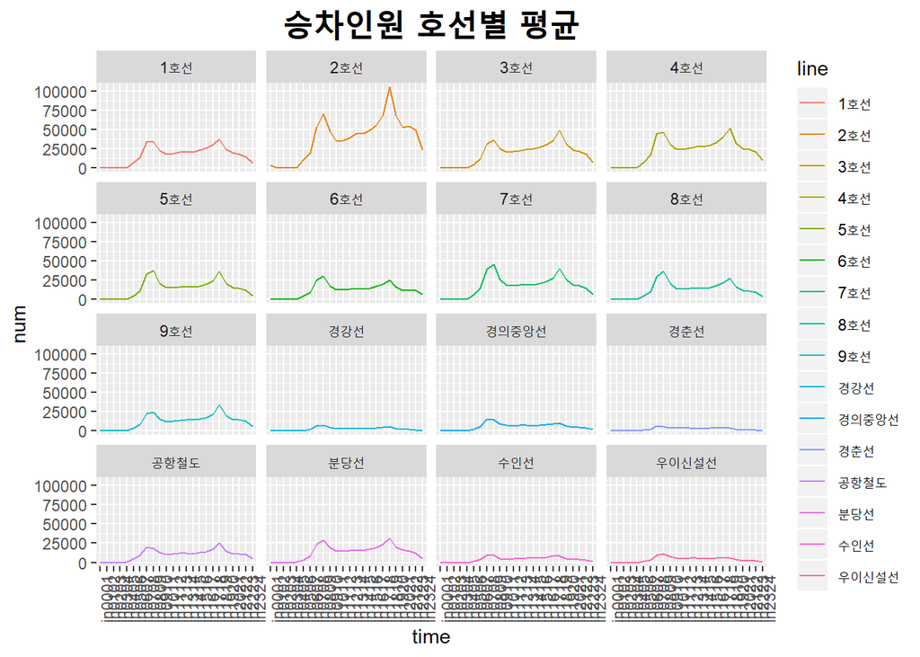

```r
ggplot(data = subin_gl, aes(x = time, y = num, col = line, group = line)) + geom_line() +
  facet_wrap(~line, ncol = 4) +
  theme(plot.title = element_text(face = "bold", hjust = 0.5, size = 20),
        axis.text.x = element_text(angle = 90)) +
  ggtitle("승차인원 호선별 평균")
```

[figure not shown]

```r
ggplot(data = subin_gl, aes(x = time, y = num, col = line, group = line)) + geom_line() +
  facet_wrap(~line, ncol = 4) +
  theme(plot.title = element_text(face = "bold", hjust = 0.5, size = 20),
        axis.text.x = element_text(angle = 90)) +
  ggtitle("하차인원 호선별 평균")
```

### **승하차가 많은 호선 top3**

#### **승차가 많은 호선 top3**

```r
subin_gl %>% group_by(line) %>%
  summarise(num = mean(num)) %>% arrange(desc(num)) %>% head(3) #승차 많은 호선 top3
```

```
## # A tibble: 3 x 2
##   line     num
##   <chr>  <dbl>
## 1 2호선 38740.
## 2 4호선 22687.
## 3 3호선 19528.
```

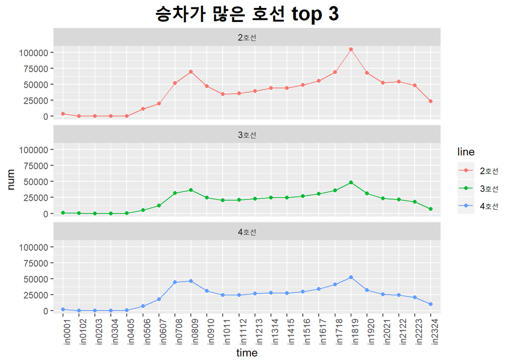

```r
toplin <- subin_gl %>% filter(line == "2호선" | line == "4호선" | line == "3호선")

ggplot(data = toplin, aes(x = time, y = num, col = line, group = line)) +
  geom_line() + geom_point() + facet_wrap(~line, ncol = 1) +
  theme(plot.title = element_text(face = "bold", hjust = 0.5, size = 20),
        axis.text.x = element_text(angle = 90)) +
  ggtitle("승차가 많은 호선 top 3") #facet_wrap 이용한 ggplot
```

ggplot의 `facet_wrap()`을 이용하여 각각의 그래프로 나타나게 했었다.  
하지만 비슷한 형태로 보일뿐 차이가 느껴지지 않았다.

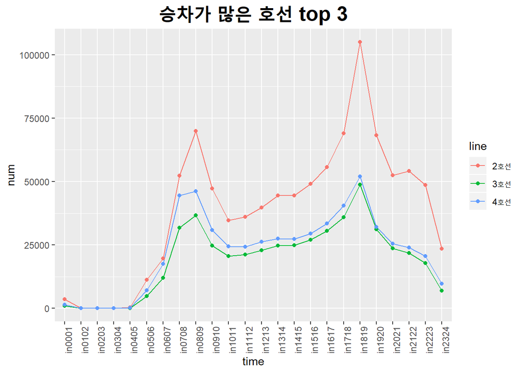

```r
ggplot(data = toplin, aes(x = time, y = num, col = line, group = line)) +
  geom_line() + geom_point() +
  theme(plot.title = element_text(face = "bold", hjust = 0.5, size = 20),
        axis.text.x = element_text(angle = 90)) +
  ggtitle("승차가 많은 호선 top 3")
```

차이를 보여주기 위해선 `facet_wrap()`을 이용하기 보다는 하나의 그래프에 나타내는게 더 효과적이다.

#### **하차가 많은 호선 top3**

```r
subout_gl %>% group_by(line) %>%
  summarise(num = mean(num)) %>% arrange(desc(num)) %>% head(3) #하차 많은 호선 top3
```

```
## # A tibble: 3 x 2
##   line     num
##   <chr>  <dbl>
## 1 2호선 39212.
## 2 4호선 22656.
## 3 3호선 19525.
```

[figure not shown]

```r
toplout <- subout_gl %>% filter(line == "2호선" | line == "4호선" | line == "3호선")

ggplot(data = toplin, aes(x = time, y = num, col = line, group = line)) +
  geom_line() + geom_point() + facet_wrap(~line, ncol = 1) +
  theme(plot.title = element_text(face = "bold", hjust = 0.5, size = 20),
        axis.text.x = element_text(angle = 90)) +
  ggtitle("하차가 많은 호선 top 3") #facet_wrap 이용한 ggplot
```

[figure not shown]

```r
ggplot(data = toplin, aes(x = time, y = num, col = line, group = line)) +
  geom_line() + geom_point() +
  theme(plot.title = element_text(face = "bold", hjust = 0.5, size = 20),
        axis.text.x = element_text(angle = 90)) +
  ggtitle("하차가 많은 호선 top 3")
```

#### **이 역만은 피하자.. 승하차 인원이 많은 top10**

```r
subin_ls <- subin %>% group_by(line, station) %>%
  summarise(in0405 = mean(in0405), in0506 = mean(in0506), in0607 = mean(in0607),
            in0708 = mean(in0708), in0809 = mean(in0809), in0910 = mean(in0910),
            in1011 = mean(in1011), in1112 = mean(in1112), in1213 = mean(in1213),
            in1314 = mean(in1314), in1415 = mean(in1415), in1516 = mean(in1516),
            in1617 = mean(in1617), in1718 = mean(in1718), in1819 = mean(in1819),
            in1920 = mean(in1920), in2021 = mean(in2021), in2122 = mean(in2122),
            in2223 = mean(in2223), in2324 = mean(in2324), in0001 = mean(in0001),
            in0102 = mean(in0102), in0203 = mean(in0203), in0304 = mean(in0304))

subout_ls <- subout %>% group_by(line, station) %>%
  summarise(out0405 = mean(out0405), out0506 = mean(out0506), out0607 = mean(out0607),
            out0708 = mean(out0708), out0809 = mean(out0809), out0910 = mean(out0910),
            out1011 = mean(out1011), out1112 = mean(out1112), out1213 = mean(out1213),
            out1314 = mean(out1314), out1415 = mean(out1415), out1516 = mean(out1516),
            out1617 = mean(out1617), out1718 = mean(out1718), out1819 = mean(out1819),
            out1920 = mean(out1920), out2021 = mean(out2021), out2122 = mean(out2122),
            out2223 = mean(out2223), out2324 = mean(out2324), out0001 = mean(out0001),
            out0102 = mean(out0102), out0203 = mean(out0203), out0304 = mean(out0304))
```

#### **출근시간대 07시 ~ 09시 승차인원**

```r
boom <- subin_ls %>% mutate(t0709 = in0708+in0809)%>%
  select(line, station, t0709) %>% arrange(desc(t0709)) %>% head(10)
boom #07-09시 승차인원 top10
```

```
## # A tibble: 10 x 3
## # Groups:   line [4]
##    line  station          t0709
##    <chr> <chr>            <dbl>
##  1 2호선 신림           598471
##  2 2호선 구로디지털단지 361121.
##  3 2호선 잠실           354603.
##  4 3호선 연신내         344450.
##  5 2호선 서울대입구     344104.
##  6 4호선 수유(강북구청) 338934.
##  7 2호선 신도림         330669.
##  8 4호선 쌍문           315449.
##  9 5호선 까치산         306968.
## 10 5호선 화곡           281694.
```

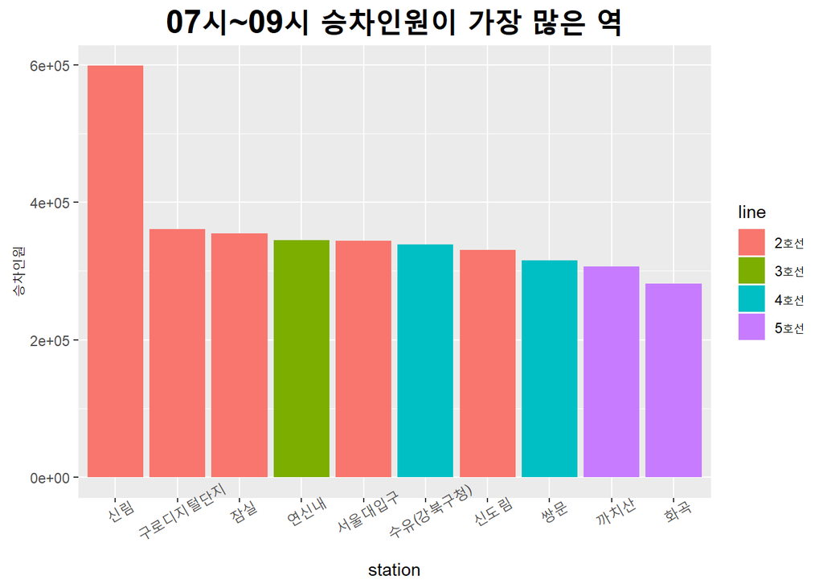

```r
ggplot(boom, aes(x = station, y = t0709, fill = line)) +
  geom_bar(stat = "identity")+
  theme(plot.title = element_text(face = "bold", hjust = 0.5, size = 20),
        axis.text.x = element_text(angle = 30)) +
  ggtitle("07시~09시 승차인원이 가장 많은 역") + ylab("승차인원") +
  scale_x_discrete(limits = c("신림", "구로디지털단지", "잠실", "연신내",
                              "서울대입구", "수유(강북구청)",
                              "신도림", "쌍문", "까치산", "화곡"))
```

#### **출근시간대 07 ~ 09시 하차인원**

```r
boom <- subout_ls %>% mutate(t0709 = out0708+out0809)%>%
  select(line, station, t0709) %>% arrange(desc(t0709)) %>% head(10)
boom #07-09시 하차인원 top10
```

```
## # A tibble: 10 x 3
## # Groups:   line [5]
##    line  station          t0709
##    <chr> <chr>            <dbl>
##  1 2호선 강남           550919.
##  2 7호선 가산디지털단지 526652.
##  3 2호선 역삼           481103.
##  4 2호선 을지로입구     467428.
##  5 2호선 삼성           466161.
##  6 2호선 선릉           416121.
##  7 5호선 광화문         401776.
##  8 1호선 종각           381850.
##  9 3호선 양재           378463.
## 10 2호선 구로디지털단지 360223.
```

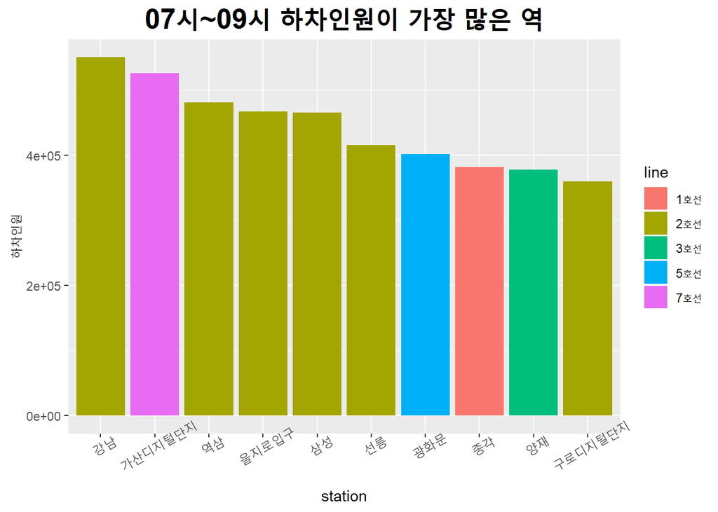

```r
ggplot(boom, aes(x = station, y = t0709, fill = line)) +
  geom_bar(stat = "identity")+
  theme(plot.title = element_text(face = "bold", hjust = 0.5, size = 20),
        axis.text.x = element_text(angle = 30)) +
  ggtitle("07시~09시 하차인원이 가장 많은 역") + ylab("하차인원") +
  scale_x_discrete(limits = c("강남", "가산디지털단지", "역삼",
                              "을지로입구", "삼성", "선릉",
                              "광화문", "종각", "양재", "구로디지털단지"))
```

#### **퇴근시간대 18 ~ 20 시 승차인원**

```r
boom <- subin_ls %>% mutate(t1820 = in1819+in1920) %>%
  select(line, station, t1820) %>% arrange(desc(t1820)) %>% head(10)
boom #18-20시 승차인원 top10
```

```
## # A tibble: 10 x 3
## # Groups:   line [3]
##    line  station          t1820
##    <chr> <chr>            <dbl>
##  1 2호선 강남           653063.
##  2 2호선 삼성           509451.
##  3 7호선 가산디지털단지 474010.
##  4 2호선 선릉           464361.
##  5 2호선 을지로입구     454412.
##  6 2호선 잠실           453989.
##  7 2호선 역삼           443350.
##  8 2호선 홍대입구       388619.
##  9 2호선 구로디지털단지 388618.
## 10 1호선 종각           374519.
```

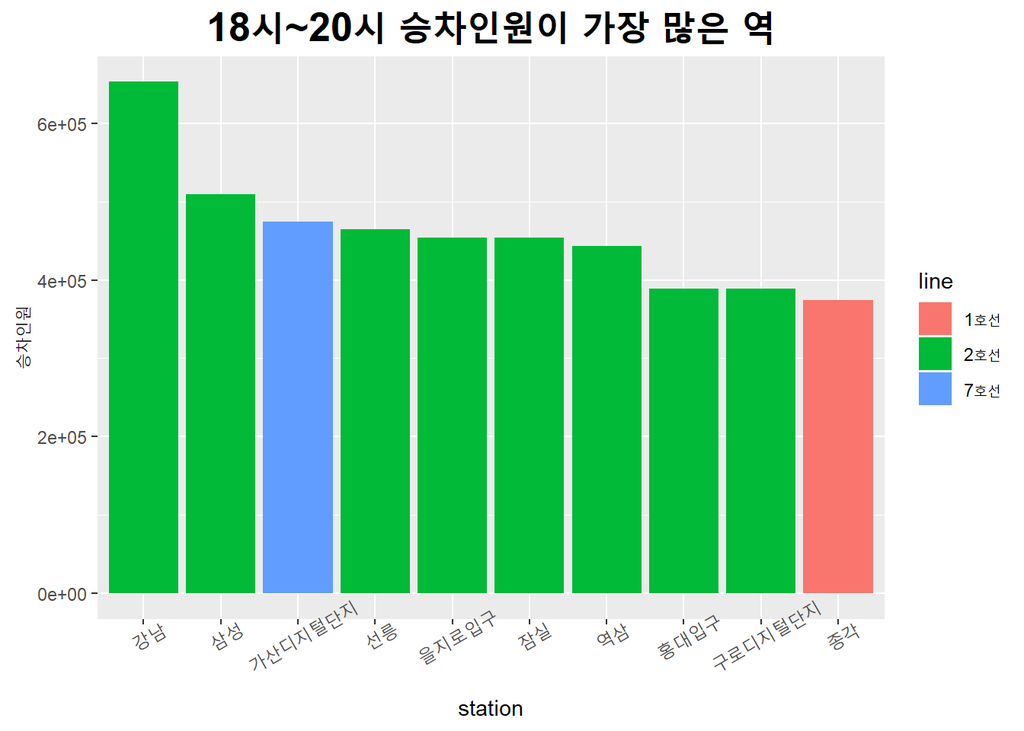

```r
ggplot(boom, aes(x = station, y = t1820, fill = line)) +
  geom_bar(stat = "identity")+
  theme(plot.title = element_text(face = "bold", hjust = 0.5, size = 20),
        axis.text.x = element_text(angle = 30)) +
  ggtitle("18시~20시 승차인원이 가장 많은 역") + ylab("승차인원") +
  scale_x_discrete(limits = c("강남", "삼성", "가산디지털단지",
                              "선릉", "을지로입구", "잠실",
                              "역삼", "홍대입구", "구로디지털단지", "종각"))
```

#### **퇴근시간대 18 ~ 20 시 하차인원**

```r
boom <- subout_ls %>% mutate(t1820 = out1819+out1920) %>%
  select(line, station, t1820) %>% arrange(desc(t1820)) %>% head(10)
boom #18-20시 하차인원 top10
```

```
## # A tibble: 10 x 3
## # Groups:   line [2]
##    line  station          t1820
##    <chr> <chr>            <dbl>
##  1 2호선 신림           520034.
##  2 2호선 홍대입구       505389.
##  3 2호선 강남           484571.
##  4 2호선 잠실           427504.
##  5 2호선 신도림         381075.
##  6 2호선 건대입구       353034.
##  7 2호선 사당           334304.
##  8 2호선 구로디지털단지 330369.
##  9 2호선 서울대입구     327348.
## 10 1호선 부평           306741.
```

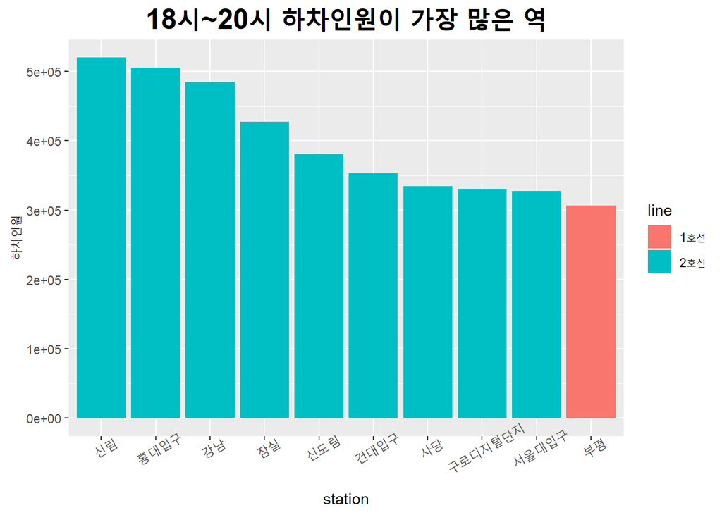

```r
ggplot(boom, aes(x = station, y = t1820, fill = line)) +
  geom_bar(stat = "identity")+
  theme(plot.title = element_text(face = "bold", hjust = 0.5, size = 20),
        axis.text.x = element_text(angle = 30)) +
  ggtitle("18시~20시 하차인원이 가장 많은 역") + ylab("하차인원") +
  scale_x_discrete(limits = c("신림", "홍대입구", "강남",
                              "잠실", "신도림", "건대입구",
                              "사당", "구로디지털단지", "서울대입구", "부평"))
```

< 아쉬운점 / 부족한점 >

1. 시간대별 X 승하차로 열이 구성되었기 때문에 다뤄야할 열이 많았다.
2. 주소를 join한 결과로 어느 지역에 인원 집중되는지 알고자하였으나 결측값이 많았다.
3. 열차시간표, 배차간격, 차량의 수가 영향을 줄 수 있다고 생각했었으나 데이터를 구하기 어려웠다. 추후 프로젝트를 진행한다면 알아볼 예정이다.  
   . .